# Métodos de Análisis de Datos 1

Unidad 1: Obtención y Preparación de Datos - Práctica

Universidad Nacional del Sur

# Contenido

Este notebook cubre:

1. **Carga de datos** desde diferentes fuentes
2. **Calidad de datos**: valores faltantes, duplicados, inconsistencias
3. **Transformación**: tipos, variables derivadas, codificación
4. **Normalización y estandarización**
5. **Discretización (binning)**
6. **Integración de datos** (joins)
7. **APIs REST**
8. **Tidy data y reshape**

# Paso 1: Carga de Datos

```r
# Cargar librerías
library(tidyverse)
library(lubridate)
library(caret)
library(naniar)
library(httr)
library(jsonlite)

# Fijar semilla
set.seed(42)

cat("Librerías cargadas correctamente\n")
```

```
## Librerías cargadas correctamente
```

## Crear dataset de ejemplo

Vamos a crear un dataset sintético que simula datos de empleados.

```r
# Crear dataset
n <- 200

empleados <- tibble(
  id = 1:n,
  nombre = paste0('Empleado_', 1:n),
  edad = sample(22:64, n, replace = TRUE),
  departamento = sample(c('IT', 'Ventas', 'RRHH', 'Finanzas', 'Marketing'),
                       n, replace = TRUE),
  salario = sample(30000:119999, n, replace = TRUE),
  fecha_ingreso = seq(as.Date('2015-01-01'), by = '7 days', length.out = n),
  educacion = sample(c('secundaria', 'universitaria', 'posgrado'),
                    n, replace = TRUE, prob = c(0.2, 0.6, 0.2))
)

# Introducir problemas de calidad

# 1. Valores faltantes
na_indices_edad <- sample(1:nrow(empleados), 15)
na_indices_salario <- sample(1:nrow(empleados), 10)
empleados$edad[na_indices_edad] <- NA
empleados$salario[na_indices_salario] <- NA

# 2. Duplicados
empleados <- bind_rows(empleados, empleados[c(5, 10, 15), ])

# 3. Inconsistencias en texto
empleados$departamento[20:25] <- tolower(empleados$departamento[20:25])
empleados$departamento[30:32] <- '  IT  '  # Con espacios

# 4. Valores fuera de rango
empleados$edad[40] <- -5
empleados$edad[41] <- 150
empleados$salario[50] <- -10000

cat("Dataset creado:", nrow(empleados), "filas,", ncol(empleados), "columnas\n")
```

```
## Dataset creado: 203 filas, 7 columnas
```

```r
head(empleados, 10)
```

```
## # A tibble: 10 × 7
##       id nombre       edad departamento salario fecha_ingreso educacion
##    <int> <chr>       <dbl> <chr>          <dbl> <date>        <chr>
##  1     1 Empleado_1     58 Ventas         58441 2015-01-01    posgrado
##  2     2 Empleado_2     22 Marketing      65308 2015-01-08    secundaria
##  3     3 Empleado_3     46 Finanzas       33408 2015-01-15    secundaria
##  4     4 Empleado_4     31 Finanzas       62647 2015-01-22    universitaria
##  5     5 Empleado_5     57 Marketing      80387 2015-01-29    universitaria
##  6     6 Empleado_6     NA IT             61255 2015-02-05    universitaria
##  7     7 Empleado_7     45 Finanzas       36967 2015-02-12    secundaria
##  8     8 Empleado_8     28 IT             60914 2015-02-19    universitaria
##  9     9 Empleado_9     57 IT            110212 2015-02-26    secundaria
## 10    10 Empleado_10    46 Marketing     105398 2015-03-05    universitaria
```

## Exploración inicial

```r
# Estructura
cat("Estructura del dataset:\n")
```

```
## Estructura del dataset:
```

```r
str(empleados)
```

```
## tibble [203 × 7] (S3: tbl_df/tbl/data.frame)
##  $ id           : int [1:203] 1 2 3 4 5 6 7 8 9 10 ...
##  $ nombre       : chr [1:203] "Empleado_1" "Empleado_2" "Empleado_3" "Empleado_4" ...
##  $ edad         : num [1:203] 58 22 46 31 57 NA 45 28 57 46 ...
##  $ departamento : chr [1:203] "Ventas" "Marketing" "Finanzas" "Finanzas" ...
##  $ salario      : num [1:203] 58441 65308 33408 62647 80387 ...
##  $ fecha_ingreso: Date[1:203], format: "2015-01-01" "2015-01-08" ...
##  $ educacion    : chr [1:203] "posgrado" "secundaria" "secundaria" "universitaria" ...
```

```r
# Resumen estadístico
cat("\nEstadísticas descriptivas:\n")
```

```
##
## Estadísticas descriptivas:
```

```r
summary(empleados)
```

```
##        id            nombre               edad        departamento
##  Min.   :  1.00   Length:203         Min.   : -5.00   Length:203
##  1st Qu.: 48.50   Class :character   1st Qu.: 34.00   Class :character
##  Median : 99.00   Mode  :character   Median : 46.00   Mode  :character
##  Mean   : 99.16                      Mean   : 44.87
##  3rd Qu.:149.50                      3rd Qu.: 55.25
##  Max.   :200.00                      Max.   :150.00
##                                      NA's   :15
##     salario       fecha_ingreso         educacion
##  Min.   :-10000   Min.   :2015-01-01   Length:203
##  1st Qu.: 51746   1st Qu.:2015-11-29   Class :character
##  Median : 70521   Median :2016-11-17   Mode  :character
##  Mean   : 72552   Mean   :2016-11-18
##  3rd Qu.: 95989   3rd Qu.:2017-11-05
##  Max.   :119387   Max.   :2018-10-25
##  NA's   :10
```

```r
# Primeras filas
cat("Primeras 5 filas:\n")
```

```
## Primeras 5 filas:
```

```r
head(empleados)
```

```
## # A tibble: 6 × 7
##      id nombre      edad departamento salario fecha_ingreso educacion
##   <int> <chr>      <dbl> <chr>          <dbl> <date>        <chr>
## 1     1 Empleado_1    58 Ventas         58441 2015-01-01    posgrado
## 2     2 Empleado_2    22 Marketing      65308 2015-01-08    secundaria
## 3     3 Empleado_3    46 Finanzas       33408 2015-01-15    secundaria
## 4     4 Empleado_4    31 Finanzas       62647 2015-01-22    universitaria
## 5     5 Empleado_5    57 Marketing      80387 2015-01-29    universitaria
## 6     6 Empleado_6    NA IT             61255 2015-02-05    universitaria
```

```r
cat("\nÚltimas 5 filas:\n")
```

```
##
## Últimas 5 filas:
```

```r
tail(empleados)
```

```
## # A tibble: 6 × 7
##      id nombre        edad departamento salario fecha_ingreso educacion
##   <int> <chr>        <dbl> <chr>          <dbl> <date>        <chr>
## 1   198 Empleado_198    62 Marketing     102297 2018-10-11    secundaria
## 2   199 Empleado_199    46 IT             73105 2018-10-18    universitaria
## 3   200 Empleado_200    24 RRHH          100267 2018-10-25    universitaria
## 4     5 Empleado_5      57 Marketing      80387 2015-01-29    universitaria
## 5    10 Empleado_10     46 Marketing     105398 2015-03-05    universitaria
## 6    15 Empleado_15     62 Ventas         37084 2015-04-09    posgrado
```

# Paso 2: Calidad de Datos

## 2.1 Valores Faltantes

```r
# Detectar valores faltantes
cat("Valores faltantes por columna:\n")
```

```
## Valores faltantes por columna:
```

```r
missing <- colSums(is.na(empleados))
missing_pct <- (missing / nrow(empleados)) * 100

missing_df <- data.frame(
  Total = missing,
  Porcentaje = missing_pct
)

print(missing_df[missing_df$Total > 0, ])
```

```
##         Total Porcentaje
## edad       15   7.389163
## salario    10   4.926108
```

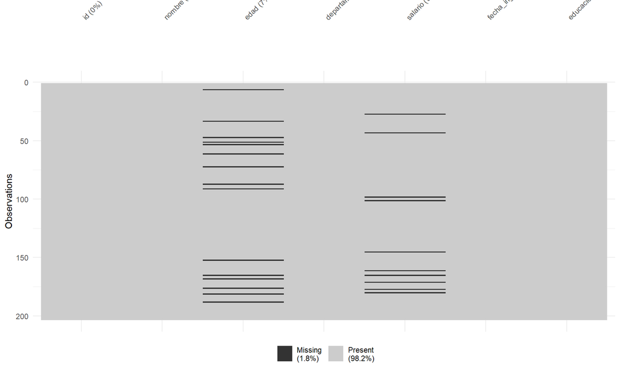

```r
# Visualizar patrón de missingness
vis_miss(empleados)
```

### Estrategia de imputación

- **Edad**: Imputar con mediana
- **Salario**: Imputar con media por departamento

```r
# Copiar dataset
df <- empleados

# Imputar edad con mediana
edad_mediana <- median(df$edad, na.rm = TRUE)
df$edad[is.na(df$edad)] <- edad_mediana
cat("Edad: imputado", sum(is.na(empleados$edad)),
    "valores con mediana =", edad_mediana, "\n")
```

```
## Edad: imputado 15 valores con mediana = 46
```

```r
# Imputar salario con media por departamento
df <- df %>%
  group_by(departamento) %>%
  mutate(salario = ifelse(is.na(salario),
                         mean(salario, na.rm = TRUE),
                         salario)) %>%
  ungroup()

cat("Salario: imputado con media por departamento\n")
```

```
## Salario: imputado con media por departamento
```

```r
# Verificar
cat("\nValores faltantes después de imputación:", sum(is.na(df)), "\n")
```

```
##
## Valores faltantes después de imputación: 0
```

## 2.2 Duplicados

```r
# Detectar duplicados
duplicados <- duplicated(df)
cat("Número de filas duplicadas:", sum(duplicados), "\n")
```

```
## Número de filas duplicadas: 3
```

```r
# Ver duplicados
if (sum(duplicados) > 0) {
  cat("\nFilas duplicadas:\n")
  print(df[duplicados, ])
}
```

```
##
## Filas duplicadas:
## # A tibble: 3 × 7
##      id nombre       edad departamento salario fecha_ingreso educacion
##   <int> <chr>       <dbl> <chr>          <dbl> <date>        <chr>
## 1     5 Empleado_5     57 Marketing      80387 2015-01-29    universitaria
## 2    10 Empleado_10    46 Marketing     105398 2015-03-05    universitaria
## 3    15 Empleado_15    62 Ventas         37084 2015-04-09    posgrado
```

```r
# Eliminar duplicados
df <- distinct(df)
cat("Dataset después de eliminar duplicados:", nrow(df), "filas\n")
```

```
## Dataset después de eliminar duplicados: 200 filas
```

## 2.3 Inconsistencias

```r
# Verificar valores únicos en departamento
cat("Valores únicos en departamento:\n")
```

```
## Valores únicos en departamento:
```

```r
table(df$departamento)
```

```
##
##      IT    finanzas  Finanzas        it        IT Marketing      rrhh      RRHH
##         3         1        35         3        40        33         1        38
##    ventas    Ventas
##         1        45
```

```r
# Estandarizar texto
df <- df %>%
  mutate(departamento = str_trim(departamento) %>% str_to_upper())

cat("\nDespués de estandarización:\n")
```

```
##
## Después de estandarización:
```

```r
table(df$departamento)
```

```
##
##  FINANZAS        IT MARKETING      RRHH    VENTAS
##        36        46        33        39        46
```

```r
# Detectar valores fuera de rango
cat("Estadísticas de edad:\n")
```

```
## Estadísticas de edad:
```

```r
cat("Min:", min(df$edad, na.rm = TRUE), "Max:", max(df$edad, na.rm = TRUE), "\n")
```

```
## Min: -5 Max: 150
```

```r
cat("\nEstadísticas de salario:\n")
```

```
##
## Estadísticas de salario:
```

```r
cat("Min:", min(df$salario, na.rm = TRUE), "Max:", max(df$salario, na.rm = TRUE), "\n")
```

```
## Min: -10000 Max: 119387
```

```r
# Detectar anormales
edad_invalida <- df$edad < 18 | df$edad > 100
salario_invalido <- df$salario < 0

cat("\nEdades inválidas:", sum(edad_invalida, na.rm = TRUE), "\n")
```

```
##
## Edades inválidas: 2
```

```r
cat("Salarios inválidos:", sum(salario_invalido, na.rm = TRUE), "\n")
```

```
## Salarios inválidos: 1
```

```r
# Corregir valores fuera de rango
df <- df %>%
  mutate(
    edad = ifelse(edad < 18 | edad > 100, NA, edad),
    salario = ifelse(salario < 0, NA, salario)
  )

# Imputar nuevamente
df <- df %>%
  mutate(
    edad = ifelse(is.na(edad), median(edad, na.rm = TRUE), edad),
    salario = ifelse(is.na(salario), mean(salario, na.rm = TRUE), salario)
  )

cat("Valores inválidos corregidos\n")
```

```
## Valores inválidos corregidos
```

```r
cat("Edad - Min:", min(df$edad), "Max:", max(df$edad), "\n")
```

```
## Edad - Min: 22 Max: 64
```

```r
cat("Salario - Min:", min(df$salario), "Max:", max(df$salario), "\n")
```

```
## Salario - Min: 31255 Max: 119387
```

# Paso 3: Transformación de Datos

## 3.1 Verificar y convertir tipos

```r
# Tipos actuales
cat("Tipos de datos:\n")
```

```
## Tipos de datos:
```

```r
sapply(df, class)
```

```
##            id        nombre          edad  departamento       salario
##     "integer"   "character"     "numeric"   "character"     "numeric"
## fecha_ingreso     educacion
##        "Date"   "character"
```

```r
# Convertir tipos
df <- df %>%
  mutate(
    id = as.character(id),
    edad = as.integer(edad),
    departamento = as.factor(departamento),
    educacion = factor(educacion,
                      levels = c('secundaria', 'universitaria', 'posgrado'),
                      ordered = TRUE)
  )

cat("\nTipos después de conversión:\n")
```

```
##
## Tipos después de conversión:
```

```r
sapply(df, class)
```

```
## $id
## [1] "character"
##
## $nombre
## [1] "character"
##
## $edad
## [1] "integer"
##
## $departamento
## [1] "factor"
##
## $salario
## [1] "numeric"
##
## $fecha_ingreso
## [1] "Date"
##
## $educacion
## [1] "ordered" "factor"
```

## 3.2 Crear variables derivadas

```r
df <- df %>%
  mutate(
    # Componentes de fecha
    año_ingreso = year(fecha_ingreso),
    mes_ingreso = month(fecha_ingreso),
    dia_semana_ingreso = wday(fecha_ingreso),

    # Antigüedad
    antiguedad_años = as.numeric(difftime(Sys.Date(), fecha_ingreso, units = "days")) / 365.25,

    # Categoría de edad
    categoria_edad = cut(edad,
                        breaks = c(0, 30, 45, 65),
                        labels = c('joven', 'mediana_edad', 'senior')),

    # Salario por hora
    salario_por_hora = salario / (40 * 52),

    # Es senior?
    es_senior = antiguedad_años > 5
  )

cat("Variables derivadas creadas\n")
```

```
## Variables derivadas creadas
```

```r
df %>%
  select(nombre, edad, categoria_edad, antiguedad_años, es_senior) %>%
  head()
```

```
## # A tibble: 6 × 5
##   nombre      edad categoria_edad antiguedad_años es_senior
##   <chr>      <int> <fct>                    <dbl> <lgl>
## 1 Empleado_1    58 senior                    11.2 TRUE
## 2 Empleado_2    22 joven                     11.2 TRUE
## 3 Empleado_3    46 senior                    11.2 TRUE
## 4 Empleado_4    31 mediana_edad              11.2 TRUE
## 5 Empleado_5    57 senior                    11.2 TRUE
## 6 Empleado_6    46 senior                    11.1 TRUE
```

## 3.3 Codificación de variables categóricas

```r
# Label encoding para educación (ordinal)
df <- df %>%
  mutate(educacion_encoded = as.numeric(educacion))

cat("Label encoding para educación:\n")
```

```
## Label encoding para educación:
```

```r
df %>%
  select(educacion, educacion_encoded) %>%
  distinct() %>%
  arrange(educacion_encoded)
```

```
## # A tibble: 3 × 2
##   educacion     educacion_encoded
##   <ord>                     <dbl>
## 1 secundaria                    1
## 2 universitaria                 2
## 3 posgrado                      3
```

```r
# One-hot encoding para departamento (nominal)
dummies <- dummyVars(" ~ departamento", data = df)
df_encoded <- bind_cols(
  df,
  as_tibble(predict(dummies, newdata = df))
)

cat("\nOne-hot encoding para departamento:\n")
```

```
##
## One-hot encoding para departamento:
```

```r
cat("Columnas agregadas:",
    names(df_encoded)[grepl("^departamento", names(df_encoded))], "\n")
```

```
## Columnas agregadas: departamento departamento.FINANZAS departamento.IT departamento.MARKETING departamento.RRHH departamento.VENTAS
```

```r
cat("Dimensiones:", nrow(df), "x", ncol(df), "→",
    nrow(df_encoded), "x", ncol(df_encoded), "\n")
```

```
## Dimensiones: 200 x 15 → 200 x 20
```

# Paso 4: Normalización y Estandarización

```r
# Columnas numéricas
numeric_cols <- c('edad', 'salario', 'antiguedad_años')
```

## 4.1 Min-Max Scaling

```r
# Aplicar Min-Max
preproc_minmax <- preProcess(df[, numeric_cols], method = "range")
df_minmax <- df
df_minmax[, numeric_cols] <- predict(preproc_minmax, df[, numeric_cols])

cat("Antes de Min-Max:\n")
```

```
## Antes de Min-Max:
```

```r
summary(df[, numeric_cols])
```

```
##       edad          salario       antiguedad_años
##  Min.   :22.00   Min.   : 31255   Min.   : 7.428
##  1st Qu.:35.00   1st Qu.: 52720   1st Qu.: 8.381
##  Median :46.00   Median : 71542   Median : 9.335
##  Mean   :44.53   Mean   : 72931   Mean   : 9.335
##  3rd Qu.:54.25   3rd Qu.: 94449   3rd Qu.:10.288
##  Max.   :64.00   Max.   :119387   Max.   :11.242
```

```r
cat("\nDespués de Min-Max:\n")
```

```
##
## Después de Min-Max:
```

```r
summary(df_minmax[, numeric_cols])
```

```
##       edad           salario       antiguedad_años
##  Min.   :0.0000   Min.   :0.0000   Min.   :0.00
##  1st Qu.:0.3095   1st Qu.:0.2436   1st Qu.:0.25
##  Median :0.5714   Median :0.4571   Median :0.50
##  Mean   :0.5365   Mean   :0.4729   Mean   :0.50
##  3rd Qu.:0.7679   3rd Qu.:0.7170   3rd Qu.:0.75
##  Max.   :1.0000   Max.   :1.0000   Max.   :1.00
```

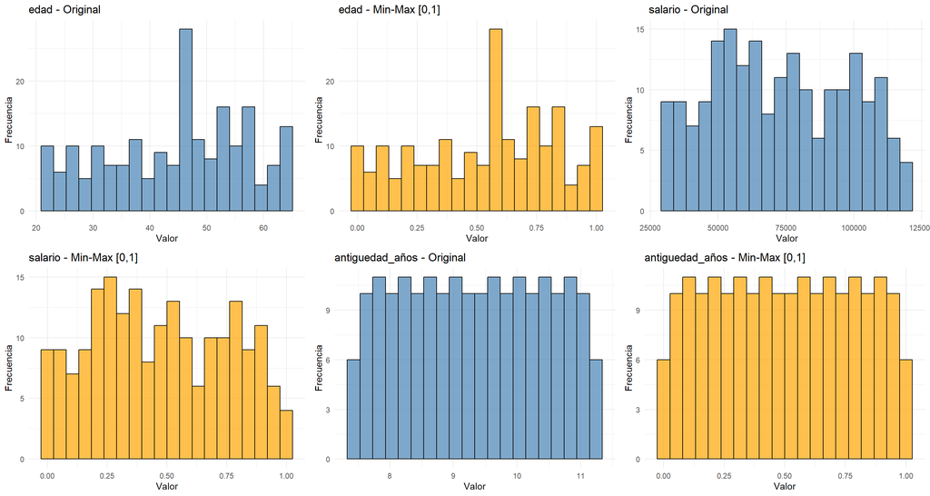

```r
# Visualizar distribuciones
library(gridExtra)

plots <- list()
for (col in numeric_cols) {
  # Original
  p1 <- ggplot(df, aes_string(x = col)) +
    geom_histogram(bins = 20, fill = "steelblue", color = "black", alpha = 0.7) +
    labs(title = paste(col, "- Original"), x = "Valor", y = "Frecuencia") +
    theme_minimal()

  # Normalizado
  p2 <- ggplot(df_minmax, aes_string(x = col)) +
    geom_histogram(bins = 20, fill = "orange", color = "black", alpha = 0.7) +
    labs(title = paste(col, "- Min-Max [0,1]"), x = "Valor", y = "Frecuencia") +
    theme_minimal()

  plots[[length(plots) + 1]] <- p1
  plots[[length(plots) + 1]] <- p2
}

do.call(grid.arrange, c(plots, ncol = 3))
```

## 4.2 Standardization (Z-score)

```r
# Aplicar Standardization
preproc_std <- preProcess(df[, numeric_cols], method = c("center", "scale"))
df_std <- df
df_std[, numeric_cols] <- predict(preproc_std, df[, numeric_cols])

cat("Después de Standardization:\n")
```

```
## Después de Standardization:
```

```r
summary(df_std[, numeric_cols])
```

```
##       edad            salario         antiguedad_años
##  Min.   :-1.8596   Min.   :-1.67950   Min.   :-1.7191
##  1st Qu.:-0.7868   1st Qu.:-0.81448   1st Qu.:-0.8595
##  Median : 0.1209   Median :-0.05598   Median : 0.0000
##  Mean   : 0.0000   Mean   : 0.00000   Mean   : 0.0000
##  3rd Qu.: 0.8017   3rd Qu.: 0.86714   3rd Qu.: 0.8595
##  Max.   : 1.6062   Max.   : 1.87213   Max.   : 1.7191
```

```r
cat("\nNota: Media ~0, Std ~1\n")
```

```
##
## Nota: Media ~0, Std ~1
```

# Paso 5: Discretización (Binning)

```r
# Bins de igual ancho
df <- df %>%
  mutate(salario_bins_ancho = cut(salario,
                                   breaks = 5,
                                   labels = c('muy_bajo', 'bajo', 'medio',
                                             'alto', 'muy_alto')))

cat("Bins de igual ancho (salario):\n")
```

```
## Bins de igual ancho (salario):
```

```r
table(df$salario_bins_ancho)
```

```
##
## muy_bajo     bajo    medio     alto muy_alto
##       38       52       41       35       34
```

```r
# Bins personalizados
df <- df %>%
  mutate(salario_bins_custom = cut(salario,
                                    breaks = c(0, 40000, 60000, 80000, 120000),
                                    labels = c('entrada', 'junior', 'mid', 'senior')))

cat("\nBins personalizados (salario):\n")
```

```
##
## Bins personalizados (salario):
```

```r
table(df$salario_bins_custom)
```

```
##
## entrada  junior     mid  senior
##      23      48      50      79
```

```r
# Cuartiles
df <- df %>%
  mutate(salario_cuartiles = cut(salario,
                                  breaks = quantile(salario, probs = seq(0, 1, 0.25)),
                                  labels = c('Q1', 'Q2', 'Q3', 'Q4'),
                                  include.lowest = TRUE))

cat("\nCuartiles (salario):\n")
```

```
##
## Cuartiles (salario):
```

```r
table(df$salario_cuartiles)
```

```
##
## Q1 Q2 Q3 Q4
## 50 50 50 50
```

```r
cat("\nNota: Cada cuartil tiene aproximadamente el mismo número de observaciones\n")
```

```
##
## Nota: Cada cuartil tiene aproximadamente el mismo número de observaciones
```

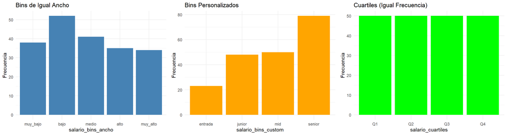

```r
# Visualizar binning
p1 <- ggplot(df, aes(x = salario_bins_ancho)) +
  geom_bar(fill = "steelblue") +
  labs(title = "Bins de Igual Ancho", y = "Frecuencia") +
  theme_minimal()

p2 <- ggplot(df, aes(x = salario_bins_custom)) +
  geom_bar(fill = "orange") +
  labs(title = "Bins Personalizados", y = "Frecuencia") +
  theme_minimal()

p3 <- ggplot(df, aes(x = salario_cuartiles)) +
  geom_bar(fill = "green") +
  labs(title = "Cuartiles (Igual Frecuencia)", y = "Frecuencia") +
  theme_minimal()

grid.arrange(p1, p2, p3, ncol = 3)
```

# Paso 6: Integración de Datos

Crear tabla de evaluaciones y combinar con empleados.

```r
# Tabla de evaluaciones
set.seed(42)

ids_evaluados <- sample(df$id, 150, replace = FALSE)

evaluaciones <- tibble(
  empleado_id = ids_evaluados,
  puntaje = sample(1:5, 150, replace = TRUE),
  fecha_evaluacion = seq(as.Date('2024-01-01'), by = '1 day', length.out = 150),
  comentarios = sample(c('Buen desempeño', 'Necesita mejorar'),
                      150, replace = TRUE)
)

cat("Tabla de evaluaciones:\n")
```

```
## Tabla de evaluaciones:
```

```r
head(evaluaciones)
```

```
## # A tibble: 6 × 4
##   empleado_id puntaje fecha_evaluacion comentarios
##   <chr>         <int> <date>           <chr>
## 1 49                3 2024-01-01       Buen desempeño
## 2 65                2 2024-01-02       Buen desempeño
## 3 153               1 2024-01-03       Buen desempeño
## 4 74                4 2024-01-04       Buen desempeño
## 5 146               5 2024-01-05       Necesita mejorar
## 6 122               2 2024-01-06       Buen desempeño
```

```r
cat("\nShape:", nrow(evaluaciones), "x", ncol(evaluaciones), "\n")
```

```
##
## Shape: 150 x 4
```

## 6.1 Inner Join

```r
# Inner join
df_inner <- inner_join(df, evaluaciones, by = c("id" = "empleado_id"))

cat("Inner join:", nrow(df_inner), "filas\n")
```

```
## Inner join: 150 filas
```

```r
cat("Original empleados:", nrow(df), "Evaluaciones:", nrow(evaluaciones), "\n")
```

```
## Original empleados: 200 Evaluaciones: 150
```

```r
cat("Resultado: solo empleados que tienen evaluación\n")
```

```
## Resultado: solo empleados que tienen evaluación
```

## 6.2 Left Join

```r
# Left join
df_left <- left_join(df, evaluaciones, by = c("id" = "empleado_id"))

cat("Left join:", nrow(df_left), "filas\n")
```

```
## Left join: 200 filas
```

```r
cat("\nEmpleados sin evaluación:", sum(is.na(df_left$puntaje)), "\n")
```

```
##
## Empleados sin evaluación: 50
```

```r
cat("Empleados con evaluación:", sum(!is.na(df_left$puntaje)), "\n")
```

```
## Empleados con evaluación: 150
```

```r
# Ver empleados sin evaluación
sin_evaluacion <- df_left %>%
  filter(is.na(puntaje)) %>%
  select(nombre, departamento, puntaje)

cat("Empleados sin evaluación (primeros 5):\n")
```

```
## Empleados sin evaluación (primeros 5):
```

```r
head(sin_evaluacion, 5)
```

```
## # A tibble: 5 × 3
##   nombre      departamento puntaje
##   <chr>       <fct>          <int>
## 1 Empleado_7  FINANZAS          NA
## 2 Empleado_8  IT                NA
## 3 Empleado_10 MARKETING         NA
## 4 Empleado_11 RRHH              NA
## 5 Empleado_17 MARKETING         NA
```

# Paso 7: Acceso a APIs REST

Usar API pública JSONPlaceholder.

```r
# GET request
url <- "https://jsonplaceholder.typicode.com/users"
response <- GET(url)

if (status_code(response) == 200) {
  usuarios <- content(response, as = "text")
  df_usuarios <- fromJSON(usuarios)

  cat("Usuarios obtenidos de la API:\n")
  df_usuarios %>%
    select(id, name, email, phone) %>%
    head()
}
```

```
## Usuarios obtenidos de la API:
```

```
##   id                 name                     email                 phone
## 1  1        Leanne Graham         Sincere@april.biz 1-770-736-8031 x56442
## 2  2         Ervin Howell         Shanna@melissa.tv   010-692-6593 x09125
## 3  3     Clementine Bauch        Nathan@yesenia.net        1-463-123-4447
## 4  4     Patricia Lebsack Julianne.OConner@kory.org     493-170-9623 x156
## 5  5     Chelsey Dietrich  Lucio_Hettinger@annie.ca         (254)954-1289
## 6  6 Mrs. Dennis Schulist   Karley_Dach@jasper.info  1-477-935-8478 x6430
```

```r
# GET con parámetros
url_posts <- "https://jsonplaceholder.typicode.com/posts"
response <- GET(url_posts, query = list(userId = 1))

if (status_code(response) == 200) {
  posts <- content(response, as = "text")
  df_posts <- fromJSON(posts)

  cat("\nPosts del usuario 1:", nrow(df_posts), "posts\n")
  df_posts %>%
    select(id, title) %>%
    head()
}
```

```
##
## Posts del usuario 1: 10 posts
```

```
##   id                                                                      title
## 1  1 sunt aut facere repellat provident occaecati excepturi optio reprehenderit
## 2  2                                                               qui est esse
## 3  3                ea molestias quasi exercitationem repellat qui ipsa sit aut
## 4  4                                                       eum et est occaecati
## 5  5                                                         nesciunt quas odio
## 6  6                                         dolorem eum magni eos aperiam quia
```

```r
# POST request
nuevo_post <- list(
  title = 'Mi nuevo post desde R',
  body = 'Este es el contenido de mi post',
  userId = 1
)

response <- POST(url_posts, body = nuevo_post, encode = "json")

if (status_code(response) == 201) {
  cat("\nPost creado exitosamente:\n")
  print(content(response))
}
```

```
##
## Post creado exitosamente:
## $title
## [1] "Mi nuevo post desde R"
##
## $body
## [1] "Este es el contenido de mi post"
##
## $userId
## [1] 1
##
## $id
## [1] 101
```

# Paso 8: Tidy Data y Reshape

## 8.1 Wide → Long (Pivot Longer)

```r
# Dataset wide
ventas_wide <- tibble(
  producto = c('A', 'B', 'C'),
  `2022` = c(100, 150, 200),
  `2023` = c(120, 180, 210),
  `2024` = c(140, 200, 230)
)

cat("Dataset WIDE (cada año es una columna):\n")
```

```
## Dataset WIDE (cada año es una columna):
```

```r
ventas_wide
```

```
## # A tibble: 3 × 4
##   producto `2022` `2023` `2024`
##   <chr>     <dbl>  <dbl>  <dbl>
## 1 A           100    120    140
## 2 B           150    180    200
## 3 C           200    210    230
```

```r
# Pivot longer: Wide → Long
ventas_long <- ventas_wide %>%
  pivot_longer(
    cols = c(`2022`, `2023`, `2024`),
    names_to = "año",
    values_to = "ventas"
  )

cat("\nDataset LONG (tidy):\n")
```

```
##
## Dataset LONG (tidy):
```

```r
ventas_long
```

```
## # A tibble: 9 × 3
##   producto año   ventas
##   <chr>    <chr>  <dbl>
## 1 A        2022     100
## 2 A        2023     120
## 3 A        2024     140
## 4 B        2022     150
## 5 B        2023     180
## 6 B        2024     200
## 7 C        2022     200
## 8 C        2023     210
## 9 C        2024     230
```

## 8.2 Long → Wide (Pivot Wider)

```r
# Pivot wider: Long → Wide
ventas_wide_again <- ventas_long %>%
  pivot_wider(
    names_from = año,
    values_from = ventas
  )

cat("Dataset convertido de LONG a WIDE nuevamente:\n")
```

```
## Dataset convertido de LONG a WIDE nuevamente:
```

```r
ventas_wide_again
```

```
## # A tibble: 3 × 4
##   producto `2022` `2023` `2024`
##   <chr>     <dbl>  <dbl>  <dbl>
## 1 A           100    120    140
## 2 B           150    180    200
## 3 C           200    210    230
```

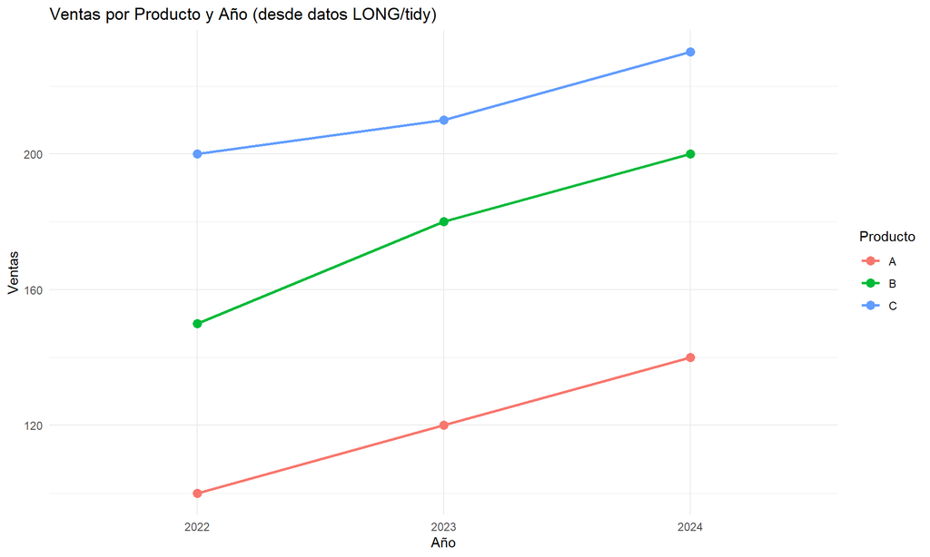

```r
# Visualizar: Long es mejor para gráficos
ggplot(ventas_long, aes(x = año, y = ventas, color = producto, group = producto)) +
  geom_line(size = 1) +
  geom_point(size = 3) +
  labs(
    title = "Ventas por Producto y Año (desde datos LONG/tidy)",
    x = "Año",
    y = "Ventas",
    color = "Producto"
  ) +
  theme_minimal()
```

# Resumen y Conclusiones

En este notebook practicamos:

## Clase 3: Fuentes de Datos y Carga

- ✓ Creación de datasets sintéticos
- ✓ Exploración inicial: `str()`, `summary()`, `head()`

## Clase 4: Calidad de Datos

- ✓ Detección de valores faltantes con `is.na()`
- ✓ Imputación simple (mediana) y por grupo (media por departamento)
- ✓ Detección y eliminación de duplicados con `distinct()`
- ✓ Estandarización de texto con `str_trim()` y `str_to_upper()`
- ✓ Corrección de valores fuera de rango

## Clase 5: Transformación

- ✓ Conversión de tipos: `as.numeric()`, `factor()`
- ✓ Variables derivadas con `mutate()`: fechas, operaciones aritméticas
- ✓ Label encoding con `as.numeric(factor())`
- ✓ One-hot encoding con `dummyVars()` de caret

## Clase 6: Normalización e Integración

- ✓ Min-Max scaling con `preProcess(method = "range")`
- ✓ Standardization con `preProcess(method = c("center", "scale"))`
- ✓ Discretización: `cut()` (igual ancho, personalizado, cuartiles)
- ✓ Joins: `inner_join()`, `left_join()`

## Clase 7: APIs y Tidy Data

- ✓ GET requests con `GET()`
- ✓ POST requests con `POST()`
- ✓ Wide → Long con `pivot_longer()`
- ✓ Long → Wide con `pivot_wider()`

## Buenas Prácticas Aplicadas

- ✓ Semilla fijada para reproducibilidad
- ✓ Uso del pipe `%>%` para código claro
- ✓ Verificación en cada paso
- ✓ Visualizaciones con ggplot2
- ✓ Código documentado

# Ejercicios Propuestos

1. **Explorar otros datasets:**
   - Usar datasets de paquetes como `datasets`, `ggplot2`
   - Aplicar pipeline completo de preparación
2. **APIs:**
   - Usar API con autenticación
   - Combinar datos de múltiples endpoints
   - Manejar paginación
3. **Imputación avanzada:**
   - Probar `mice` package
   - Comparar múltiples métodos de imputación
4. **Feature engineering:**
   - Crear interacciones entre variables
   - Transformaciones log, sqrt, Box-Cox
   - Ratios y proporciones
5. **Tidyverse avanzado:**
   - Usar `across()` para operaciones múltiples
   - Crear funciones personalizadas
   - Pipeline complejo con múltiples transformaciones